# Appendix

RafaĹ‚ Cylwa, Dariusz Matlak, Grzegorz Ziajka

10 maja 2016

Here is some code of what we tried, but wasn’t worth showing. It could potentially lead to some interesting findings but we couldn’t make anything out of it.

## 1. We tried to to investigate some regularities in time differences between vistiting consecutive exhibits.

Some commented code of data praparation:

```r
## Przygotowanie danych

#uzywam tylko odwiedzin < 4 min, zeby nie bylo problemow

#smallLogs_agr3 <- smallLogs_agr3[smallLogs_agr3$ptime < 240,]
#dane <- smallLogs_agr3[,1:4]
#Lista_f3 <- split(dane, dane$visitor)
#cond <- sapply(Lista_f3_agr, function(x) nrow(x[1]) > 5)
#Lista_f3_agr_lim <- Lista_f3_agr[cond]

#funkcja do liczenia odstepĂłw czasowych z macierzy z wizytami
#my_funct1 <- function(x) {
#
#  tmp <- x
#
#  mat_tmp <- data.frame()
#  i = 1
#
#  while(i+1 <= nrow(tmp)) {
#    vec <- as.data.frame(t(c(tmp[i, "visitor"], as.character(tmp[i, "station"]), as.character(tmp[i+1, #"station"]) )))
#    vec$diff <- difftime(tmp[i+1, "min"], tmp[i, "max"], units = "secs")
#    mat_tmp <- rbind.data.frame(mat_tmp, vec)
#    i = i+1
#  }
#  return (mat_tmp)
#}
#
#lista_odstepy <- lapply(Lista_f3_agr_lim, my_funct1)
#library(rlist)

#library(plyr)
#tab_odstepy <- ldply(lista_odstepy, data.frame)

# niestety nadal sÄ… ujemne odstepy, wywalmy je po prostu
#tab_odstepy_dod <- tab_odstepy[tab_odstepy$diff>0,]
#tab_odstepy_dod <- tab_odstepy_dod[,-1]
#colnames(tab_odstepy_dod) <- c("visitor", "s1", "s2", "diff")
#tab_odstepy_dod$przejscie <- paste(tab_odstepy_dod$s1, tab_odstepy_dod$s2, sep = " -> ")

#tab_agr <- tab_odstepy_dod[, c(1, 5, 4)]
#tab_agr$diff <- as.numeric(tab_agr$diff)
```

```r
library(arules)
library(tidyr)
```

No we want to divide variable diff into two cathegories: long and short - perform discretize.

```r
#tab_agr$long <- discretize(tab_agr$diff, method = "frequency", categories = 2, labels = c(0, 1))
#tab_agr$long <- as.integer(as.character(tab_agr$long))
```

```r
#Changing format from long to wide
#library(reshape2)
#df_rzadka <- dcast(tab_agr, visitor~przejscie, value.var="long", fill = 0)
#rownames(df_rzadka) <- df_rzadka$visitor
```

We load previously computed data for convenience.

```r
load("C:/Users/Rafal/Documents/Statystyka II/Projekt1/Faza 3/faza3_czyste/dane_krotkie/df_rzadka.rda")
```

And form transactions matrix:

```r
df_rzadka <- df_rzadka[, -1]
df_logic <- (df_rzadka != 0)
transakcje <- as(df_logic, Class = "transactions")
```

```r
rules <- apriori(transakcje, parameter = list(supp = 0.001, conf = 0.3))
```

```
## Apriori
##
## Parameter specification:
##  confidence minval smax arem  aval originalSupport support minlen maxlen
##         0.3    0.1    1 none FALSE            TRUE   0.001      1     10
##  target   ext
##   rules FALSE
##
## Algorithmic control:
##  filter tree heap memopt load sort verbose
##     0.1 TRUE TRUE  FALSE TRUE    2    TRUE
##
## Absolute minimum support count: 78
##
## set item appearances ...[0 item(s)] done [0.00s].
## set transactions ...[3400 item(s), 78376 transaction(s)] done [0.06s].
## sorting and recoding items ... [1435 item(s)] done [0.00s].
## creating transaction tree ... done [0.07s].
## checking subsets of size 1 2 3 done [0.03s].
## writing ... [4 rule(s)] done [0.00s].
## creating S4 object  ... done [0.02s].
```

```r
inspect(rules)
```

```
##   lhs                  rhs               support     confidence lift
## 1 {cnk05 -> cnk06}  => {cnk06 -> cnk19a} 0.001122793 0.3120567   7.007954
## 2 {cnk02a -> cnk06} => {cnk06 -> cnk19a} 0.003342860 0.4763636  10.697844
## 3 {cnk02b -> cnk06} => {cnk06 -> cnk19a} 0.003521486 0.4808362  10.798287
## 4 {cnk78a -> cnk23} => {cnk18 -> cnk78a} 0.006366745 0.3078347   6.057457
```

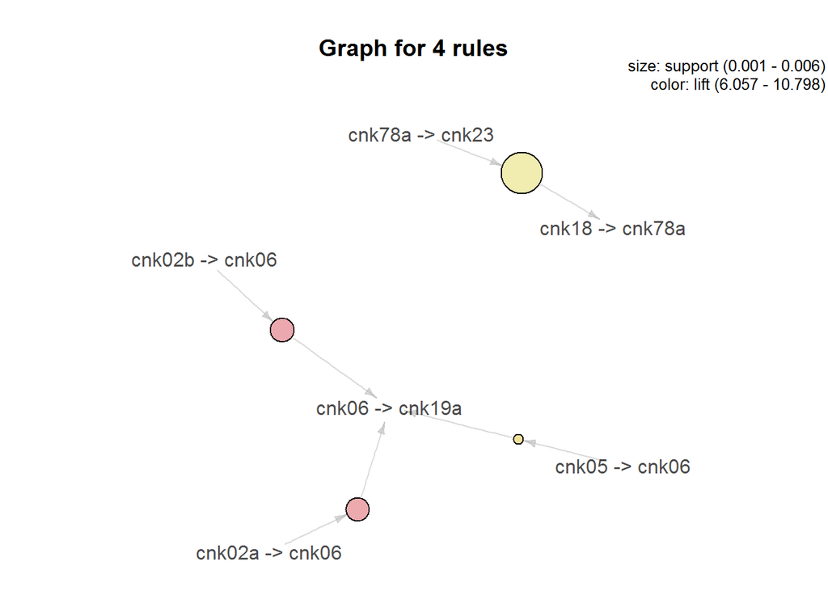

```r
library(arulesViz)
plot(rules, method = "graph")
```

We got rules like: if someone is having a long break between some 2 exhibits, he is also having a long break between some other two exhibits.

Originally we thought that we might be able to recognize queue formation, but these results are hard to interpret so we abandonned this approach.

## 2.Another observation

We also looked at time spent between stations in specific groups of exhibits.

```r
load("C:/Users/Rafal/Documents/Statystyka II/Projekt1/Faza 3/faza3_czyste/dane_krotkie/tabmerged.rda")
load("C:/Users/Rafal/Documents/Statystyka II/Projekt1/Faza 3/faza3_czyste/dane_krotkie/tab_merged_3.rda")
head(tab_merged)
```

```
##   visitor     s1     s2        przejscie     diff strefa strefa_kod
## 1 1098084 cnk02b cnk02a cnk02b -> cnk02a  98 secs     JA          1
## 2  818093 cnk100 cnk02a cnk100 -> cnk02a  25 secs     JA          1
## 3 1120015 cnk02b cnk02a cnk02b -> cnk02a   9 secs     JA          1
## 4 1040249 cnk63a cnk02a cnk63a -> cnk02a 113 secs     JA          1
## 5 1058057 cnk100 cnk02a cnk100 -> cnk02a  63 secs     JA          1
## 6  996917 cnk02b cnk02a cnk02b -> cnk02a 367 secs     JA          1
```

```r
head(tab_merged_3)
```

```
##   visitor     s1     s2        przejscie diff strefa_kod_s1 strefa_kod
## 1  912094 cnk02a  cnk12  cnk02a -> cnk12  182             1          2
## 2  843495 cnk02a  cnk06  cnk02a -> cnk06   12             1          1
## 3 1055072 cnk02a  cnk05  cnk02a -> cnk05  187             1          1
## 4  909631 cnk02a cnk100 cnk02a -> cnk100 1917             1          2
## 5  981977 cnk02a  cnk17  cnk02a -> cnk17   41             1          1
## 6  888758 cnk02a  cnk07  cnk02a -> cnk07   29             1          1
```

```r
tab_merged_cut <- tab_merged[tab_merged$diff < 6000, ]
```

For every switch between stations we assign to it a “group ID”" of the second exhibit.

Calculating means in groups we clearly see that the bigger the group number, the bigger the mean of time doffereces.

Group 1: JA

```r
mean(tab_merged_cut[tab_merged_3$strefa_kod == 1 & tab_merged_3$strefa_kod_s1 == 1, 5])
```

```
## Time difference of 208.6837 secs
```

Group 2: JA-MY-ONI

```r
mean(tab_merged_cut[tab_merged_3$strefa_kod == 2 & tab_merged_3$strefa_kod_s1 == 2, 5])
```

```
## Time difference of 225.3639 secs
```

Group 3: JA-SWIAT

```r
mean(tab_merged_cut[tab_merged_3$strefa_kod == 3 & tab_merged_3$strefa_kod_s1 == 3, 5])
```

```
## Time difference of 234.4169 secs
```

Group 4: JA-TY

```r
mean(tab_merged_cut[tab_merged_3$strefa_kod == 4 & tab_merged_3$strefa_kod_s1 == 4, 5])
```

```
## Time difference of 241.0934 secs
```

Distributions of lenghts of breaks for each group:

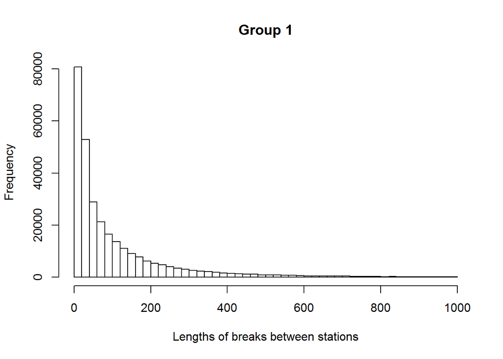

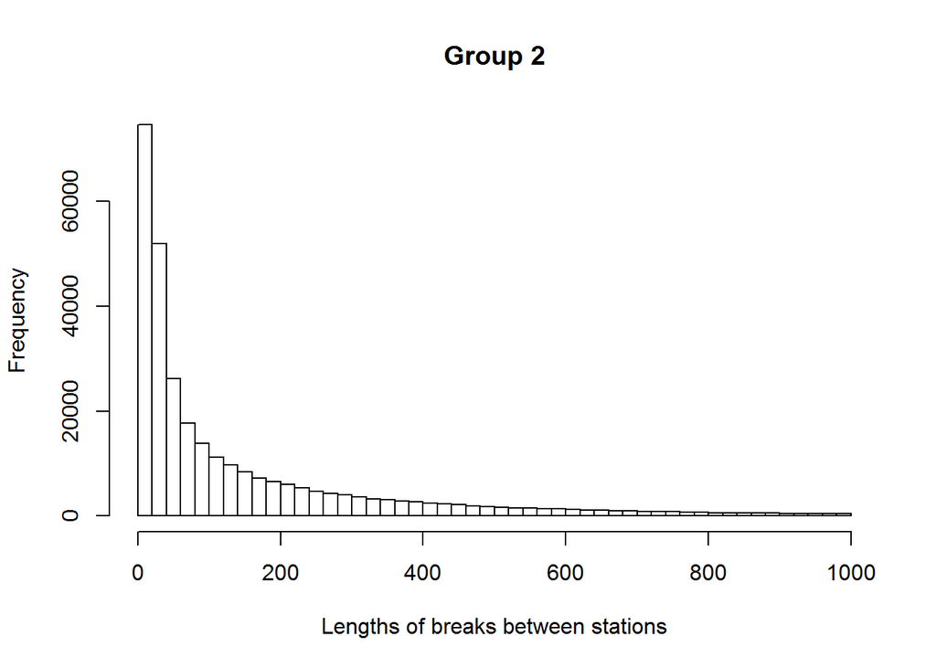

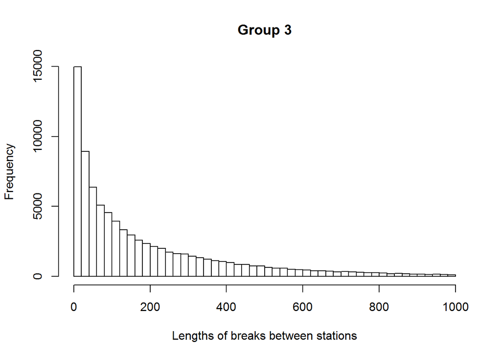

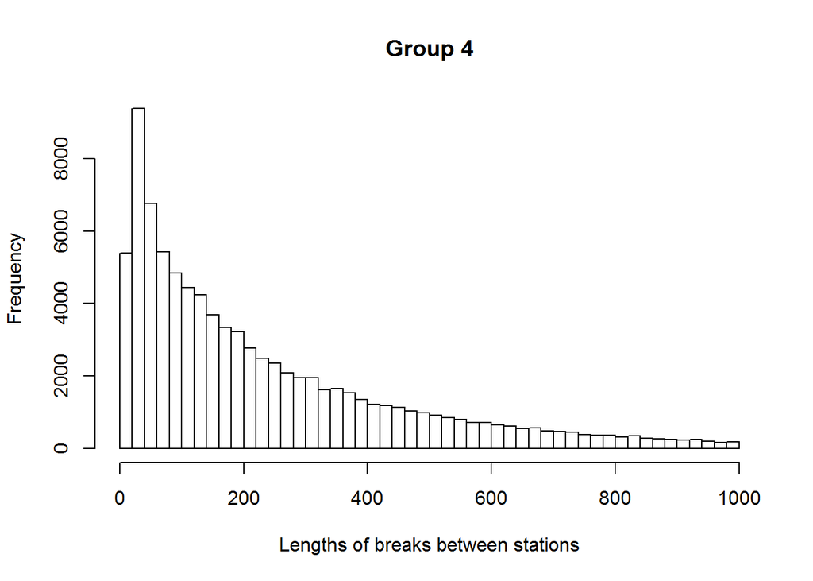

It is quite surprising that group JA-TY (smallest one, second on the map) has highest breaks lengths.

Let’s restrict only to this group.

```r
tab_ja_ty <- tab_merged_3[tab_merged_3$strefa_kod_s1 == 4 & tab_merged_3$strefa_kod == 4, ]
```

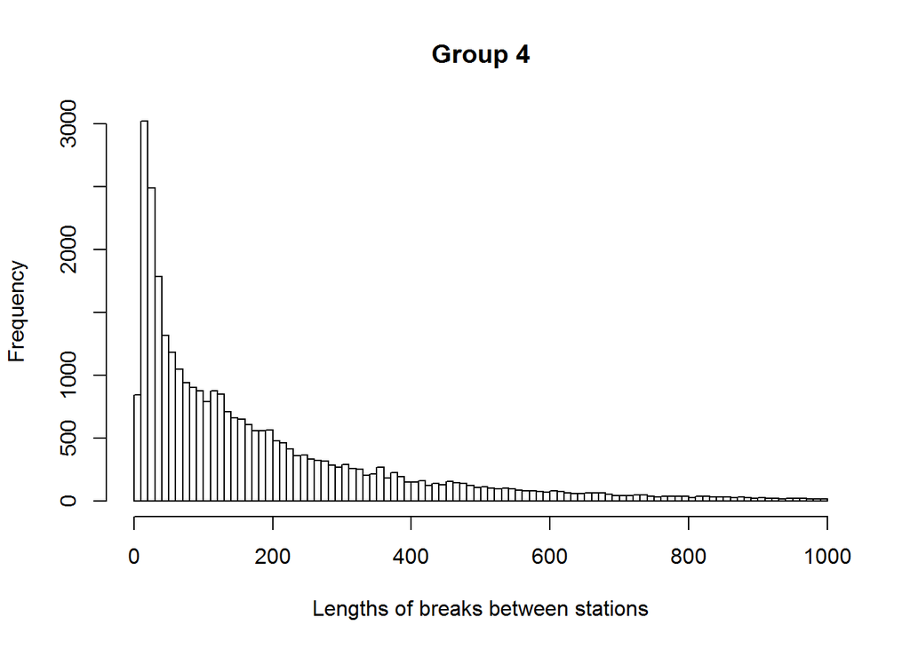

There are 8*7=56 possible pairs of exibits, in our set we have 55 unique combinations.

```r
length(unique(tab_ja_ty$przejscie))
```

```
## [1] 55
```

Can we find exhibits that are close to each other, find clusters?

We calculate mean time difference for each pair of stations:

```r
list_breaks <- split(tab_ja_ty, tab_ja_ty$przejscie)
srednie <- lapply(list_breaks, function(x) return (as.data.frame(t(c(mean(x$diff), as.character(x$s1[1]), as.character(x$s2[1]))))))

library(plyr)
tab_odstepy <- ldply(srednie, data.frame)
```

And apply kmeans, 3 clusters (close, medium, far away):

```r
clusters <- kmeans(tab_odstepy$V1, 3)
tab_odstepy$klaster <- clusters$cluster
```

“Close cluster contains:

```
## [1] "cnk18"  "cnk22"  "cnk23"  "cnk24"  "cnk25"  "cnk26"  "cnk29a" "cnk78a"
```

“Medium” cluster contains:

```
## [1] "cnk29a" "cnk18"
```

“Far away” cluster contains:

```
## [1] "cnk18"  "cnk22"  "cnk23"  "cnk24"  "cnk25"  "cnk26"  "cnk78a" "cnk29a"
```

This isn’t propably meaningfull…

END